# ASM - Exercise week 14

Anne-Kathleen Malchow & Tobias Krüger

May 15, 2021

# Q:

Modify McElreath’s model m11.7 (UBCadmissions) to include a varying intercept for “dept”. Compare to models m11.7, m11.8 and m12.1.

# A:

Load the `UCBadmit` dataset:

```r
library(rethinking)
data(UCBadmit)
d <- UCBadmit
```

Rename `applicant.gender` for better readability:

```r
names(d)[2] <- 'gid' # gender ID
str(d)
```

```
## 'data.frame':    12 obs. of  5 variables:
##  $ dept        : Factor w/ 6 levels "A","B","C","D",..: 1 1 2 2 3 3 4 4 5 5 ...
##  $ gid         : Factor w/ 2 levels "female","male": 2 1 2 1 2 1 2 1 2 1 ...
##  $ admit       : int  512 89 353 17 120 202 138 131 53 94 ...
##  $ reject      : int  313 19 207 8 205 391 279 244 138 299 ...
##  $ applications: int  825 108 560 25 325 593 417 375 191 393 ...
```

We fit the following models for comparison:

$$\begin{align*}
{\sf m}11.7: \,\, A_i &\sim {\sf Binomial}(N_i, p_i) \\
{\sf logit}(p_i) &= \alpha + \beta_{GID}\cdot GID \\
\alpha &\sim {\sf Normal}(0, 1.5) \\
\beta_{GID} &\sim {\sf Normal}(0, 1.5) \\
& \\
{\sf m}11.8: \,\, A_i &\sim {\sf Binomial}(N_i, p_i) \\
{\sf logit}(p_i) &= \delta_{DEPT[i]} + \beta_{GID}\cdot GID \\
\delta_k &\sim {\sf Normal}(0, 1.5) \\
\beta_{GID} &\sim {\sf Normal}(0, 1.5) \\
& \\
{\sf m}12.1: \,\, A_i &\sim {\sf BetaBinomial}(N_i, \bar p_i, \theta) \\
{\sf logit}(\bar p_i) &= \alpha + \beta_{GID}\cdot GID \\
\alpha &\sim {\sf Normal}(0, 1.5) \\
\beta_{GID} &\sim {\sf Normal}(0, 1.5) \\
\theta &= 2 + \phi \\
\phi &\sim {\sf Exponential}(1)\\
& \\
{\sf m}13.1: \,\, A_i &\sim {\sf Binomial}(N_i, p_i) \\
{\sf logit}(p_i) &= \bar\delta + \delta_{DEPT[i]} + \beta_{GID}\cdot GID \\
\bar\delta &\sim {\sf Normal}(0, 1.5) \\
\delta_k &\sim {\sf Normal}(0, \sigma_{\delta}) \\
\beta_{GID} &\sim {\sf Normal}(0, 1.5) \\
\sigma_{\delta} &\sim {\sf Exponential}(1) \\
\end{align*}$$

Start with re-fitting the first models from the chapter: m11.7, m11.8 and m12.1. We will use PSIS-LOO for model comparison and compute this criterion along with the model fits:

```r
library(brms)

m11.7 <-
  brm(data = d,
      family = binomial(link = "logit"),
      admit | trials(applications) ~ 1 + gid,
      prior = c(prior(normal(0, 1.5), class = Intercept),
                prior(normal(0, 1.5), class = b)))

m11.7 <- add_criterion(m11.7, "loo")

m11.8 <-
  brm(data = d,
      family = binomial(link = "logit"),
      admit | trials(applications) ~ 0 + dept + gid,
      prior = prior(normal(0, 1.5), class = b))

m11.8 <- add_criterion(m11.8, "loo")
```

```r
summary(m11.7)
```

```
##  Family: binomial
##   Links: mu = logit
## Formula: admit | trials(applications) ~ 1 + gid
##    Data: d (Number of observations: 12)
## Samples: 4 chains, each with iter = 2000; warmup = 1000; thin = 1;
##          total post-warmup samples = 4000
##
## Population-Level Effects:
##           Estimate Est.Error l-95% CI u-95% CI Rhat Bulk_ESS Tail_ESS
## Intercept    -0.83      0.05    -0.93    -0.73 1.00     2534     2420
## gidmale       0.61      0.06     0.49     0.74 1.00     2884     2649
##
## Samples were drawn using sampling(NUTS). For each parameter, Bulk_ESS
## and Tail_ESS are effective sample size measures, and Rhat is the potential
## scale reduction factor on split chains (at convergence, Rhat = 1).
```

```r
summary(m11.8)
```

```
##  Family: binomial
##   Links: mu = logit
## Formula: admit | trials(applications) ~ 0 + dept + gid
##    Data: d (Number of observations: 12)
## Samples: 4 chains, each with iter = 2000; warmup = 1000; thin = 1;
##          total post-warmup samples = 4000
##
## Population-Level Effects:
##         Estimate Est.Error l-95% CI u-95% CI Rhat Bulk_ESS Tail_ESS
## deptA       0.69      0.10     0.50     0.88 1.00     2379     2715
## deptB       0.65      0.12     0.42     0.87 1.00     2470     2876
## deptC      -0.58      0.07    -0.72    -0.43 1.00     3817     2825
## deptD      -0.61      0.09    -0.78    -0.44 1.00     3032     2961
## deptE      -1.05      0.10    -1.25    -0.85 1.00     4066     3027
## deptF      -2.61      0.16    -2.93    -2.30 1.00     3753     2239
## gidmale    -0.11      0.08    -0.27     0.06 1.00     1917     2436
##
## Samples were drawn using sampling(NUTS). For each parameter, Bulk_ESS
## and Tail_ESS are effective sample size measures, and Rhat is the potential
## scale reduction factor on split chains (at convergence, Rhat = 1).
```

The beta-binomial model is not yet implemented in `brms`. Thus, in order to fit model m12.1, we have to define a custom likelihood (i.e. `familiy`), as shown in the `brms` vignette “Define Custom Response Distributions with brms”, which covers the beta-binomial model as an example: https://cran.r-project.org/web/packages/brms/vignettes/brms_customfamilies.html

Use the code from the vignette with a little modification: We hard-code the lower bound (set to *2*) on the parameter $\theta$ ($=\phi$ in the code) that McElreath uses in his model definition of m12.1, because `set_prior()` doesn’t allow lower bounds for parameters of classes other than “b”.

```r
beta_binomial2 <- custom_family(
  "beta_binomial2", dpars = c("mu", "phi"),
  links = c("logit", "log"), lb = c(NA, 2),
  type = "int", vars = "vint1[n]"
)

stan_funs <- "
  real beta_binomial2_lpmf(int y, real mu, real phi, int T) {
    return beta_binomial_lpmf(y | T, mu * phi, (1 - mu) * phi);
  }
  int beta_binomial2_rng(real mu, real phi, int T) {
    return beta_binomial_rng(T, mu * phi, (1 - mu) * phi);
  }
"
stanvars <- stanvar(scode = stan_funs, block = "functions")
```

Now, we can fit model m12.1:

```r
m12.1 <-
  brm(data = d,
      family = beta_binomial2,
      admit | vint(applications) ~ 1 + gid ,
      prior = c(prior(normal(0, 1.5), class = Intercept),
                prior(normal(0, 1.5), class = b),
                prior(exponential(1), class = phi)),
      stanvars = stanvars)
```

We find that the posterior for $\theta$ ($= \phi$) is indeed bounded below by *2*:

```r
summary(m12.1)
```

```
##  Family: beta_binomial2
##   Links: mu = logit; phi = identity
## Formula: admit | vint(applications) ~ 1 + gid
##    Data: d (Number of observations: 12)
## Samples: 4 chains, each with iter = 2000; warmup = 1000; thin = 1;
##          total post-warmup samples = 4000
##
## Population-Level Effects:
##           Estimate Est.Error l-95% CI u-95% CI Rhat Bulk_ESS Tail_ESS
## Intercept    -0.33      0.41    -1.15     0.50 1.00     3323     2412
## gidmale      -0.12      0.55    -1.19     0.95 1.00     3023     2498
##
## Family Specific Parameters:
##     Estimate Est.Error l-95% CI u-95% CI Rhat Bulk_ESS Tail_ESS
## phi     3.04      0.82     2.04     5.03 1.00     1954      998
##
## Samples were drawn using sampling(NUTS). For each parameter, Bulk_ESS
## and Tail_ESS are effective sample size measures, and Rhat is the potential
## scale reduction factor on split chains (at convergence, Rhat = 1).
```

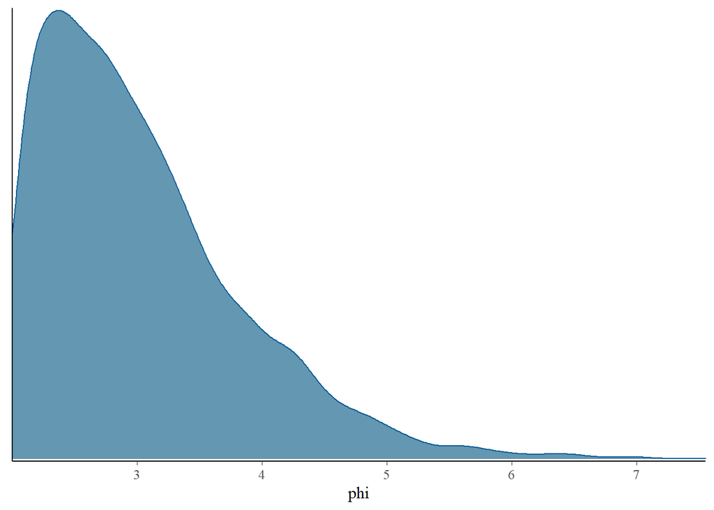

```r
mcmc_plot(m12.1, pars = "phi", type = "dens")
```

Unfortunately, using a custom distribution means that we can’t easily let STAN compute the ELPD for us, so we have to do it manually in R, using the samples from the model fit. This is also explained in the vignette mentioned above. (However, there is a little mistake: The second parameter in the function definition must be called `draws` and not `prep`.)

```r
expose_functions(m12.1, vectorize = TRUE)

log_lik_beta_binomial2 <- function(i, draws) {
  mu <- draws$dpars$mu[, i]
  phi <- draws$dpars$phi
  trials <- draws$data$vint1[i]
  y <- draws$data$Y[i]
  beta_binomial2_lpmf(y, mu, phi, trials)
}
```

Now, we can finally compute the PSIS-LOO estimate of ELPD for this model:

```r
m12.1 <- add_criterion(m12.1, "loo")
```

Lastly, we fit the new model, i.e. m11.7 with varying intercepts for the department ID:

```r
m13.1 <-
  brm(data = d,
      family = binomial(link = "logit"),
      admit | trials(applications) ~ 1 + gid + (1 | dept),
      prior = c(prior(normal(0, 1.5), class = Intercept),
                prior(normal(0, 1.5), class = b),
                prior(exponential(1), class = sd, group = 'dept')))

m13.1 <- add_criterion(m13.1, "loo", reloo = T)
```

```r
summary(m13.1)
```

```
##  Family: binomial
##   Links: mu = logit
## Formula: admit | trials(applications) ~ 1 + gid + (1 | dept)
##    Data: d (Number of observations: 12)
## Samples: 4 chains, each with iter = 2000; warmup = 1000; thin = 1;
##          total post-warmup samples = 4000
##
## Group-Level Effects:
## ~dept (Number of levels: 6)
##               Estimate Est.Error l-95% CI u-95% CI Rhat Bulk_ESS Tail_ESS
## sd(Intercept)     1.32      0.45     0.75     2.52 1.01      771     1026
##
## Population-Level Effects:
##           Estimate Est.Error l-95% CI u-95% CI Rhat Bulk_ESS Tail_ESS
## Intercept    -0.49      0.55    -1.57     0.72 1.01      577      926
## gidmale      -0.09      0.08    -0.25     0.06 1.00     2218     1850
##
## Samples were drawn using sampling(NUTS). For each parameter, Bulk_ESS
## and Tail_ESS are effective sample size measures, and Rhat is the potential
## scale reduction factor on split chains (at convergence, Rhat = 1).
```

```r
(p <- posterior_summary(m13.1))
```

```
##                         Estimate  Est.Error         Q2.5       Q97.5
## b_Intercept          -0.48570192 0.54752751  -1.57221288   0.7196723
## b_gidmale            -0.09361182 0.07896789  -0.24775662   0.0567545
## sd_dept__Intercept    1.32020519 0.45418870   0.74751285   2.5194279
## r_dept[A,Intercept]   1.15750510 0.54969288  -0.04271547   2.2443684
## r_dept[B,Intercept]   1.11142680 0.55393624  -0.08664229   2.1867871
## r_dept[C,Intercept]  -0.09860138 0.54795339  -1.28354305   0.9739438
## r_dept[D,Intercept]  -0.13181098 0.54782196  -1.30446004   0.9487225
## r_dept[E,Intercept]  -0.57274836 0.55577540  -1.76145454   0.5200211
## r_dept[F,Intercept]  -2.12093683 0.56053426  -3.32113076  -1.0269549
## lp__                -60.71056108 2.45698511 -66.39872080 -56.8457584
```

The parameter `b_Intercept` is the overall (population-level) intercept, in this case the average admission rate for female applicants across departments (on the linear predictor scale). On the response scale, this is:

```r
exp(p["b_Intercept","Estimate"])/(1+exp(p["b_Intercept","Estimate"]))
```

```
## [1] 0.3809066
```

As full posterior distribution:

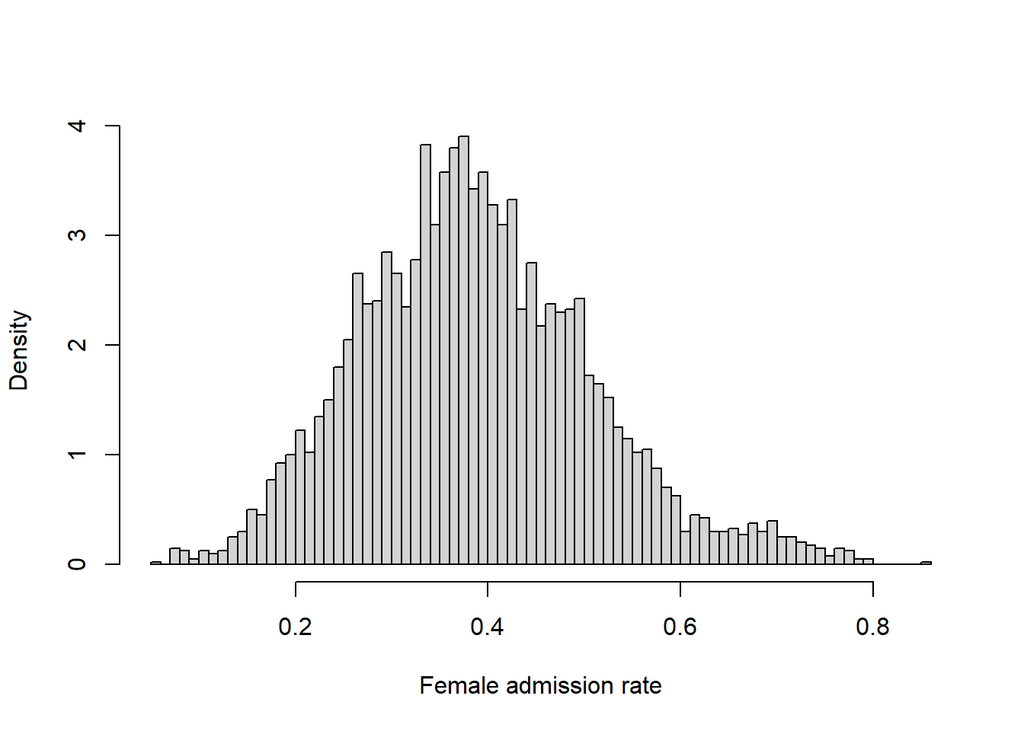

```r
ps <- posterior_samples(m13.1)
hist(exp(ps$b_Intercept)/(1+exp(ps$b_Intercept)), 100, freq = F,
     xlab = "Female admission rate",
     main = "")
```

The parameter `b_gidmale` quantifies the change in admission rate for male applicants (on the linear predictor scale). So the average admission rate across departments for males on the response scale is:

```r
exp(p["b_Intercept","Estimate"]+p["b_gidmale","Estimate"])/
  (1+exp(p["b_Intercept","Estimate"]+p["b_gidmale","Estimate"]))
```

```
## [1] 0.3590905
```

As full posterior distribution:

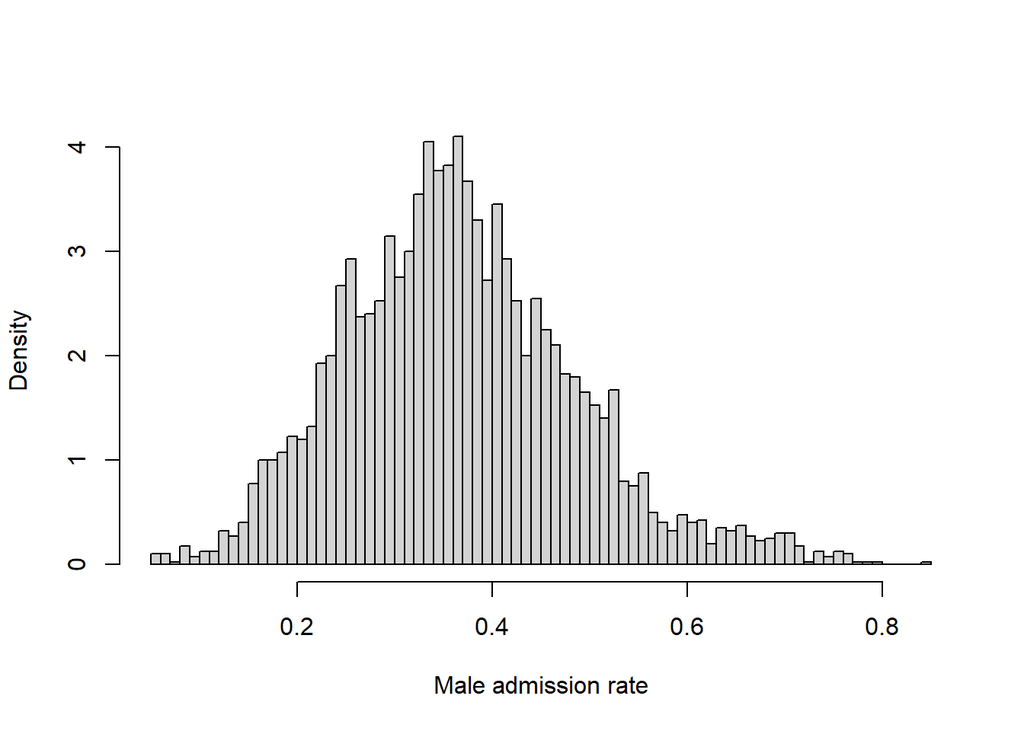

```r
hist(exp(ps$b_Intercept+ps$b_gidmale)/(1+exp(ps$b_Intercept+ps$b_gidmale)), 100, freq = F,
     xlab = "Male admission rate",
     main = "")
```

Contrast:

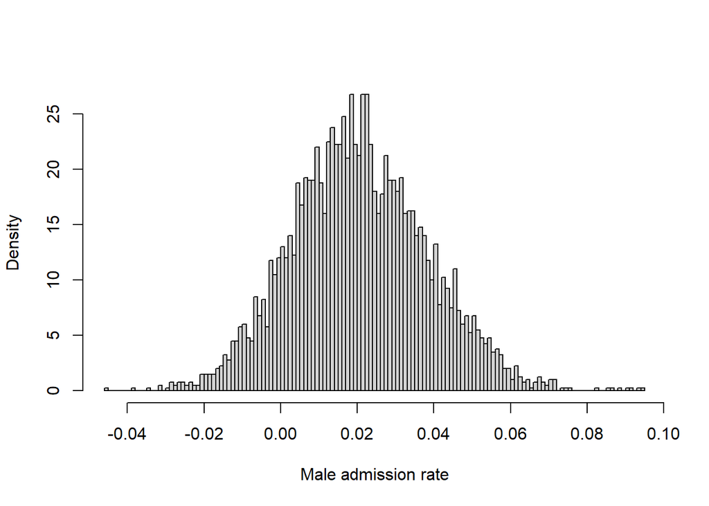

```r
hist(exp(ps$b_Intercept)/(1+exp(ps$b_Intercept))-
       exp(ps$b_Intercept+ps$b_gidmale)/(1+exp(ps$b_Intercept+ps$b_gidmale)),
     100, freq = F,
     xlab = "Male admission rate",
     main = "")
```

So, after accounting for *department*, female applicants have an around 2% greater chance of admission than male applicants, but with a large uncertainty that puts a sizable mass of the posterior probability below zero.

The admission rates vary across departments around the averages according to a common normal distribution with standard deviation `sd_dept__Intercept`:

```r
p['sd_dept__Intercept','Estimate']
```

```
## [1] 1.320205
```

As full posterior distribution:

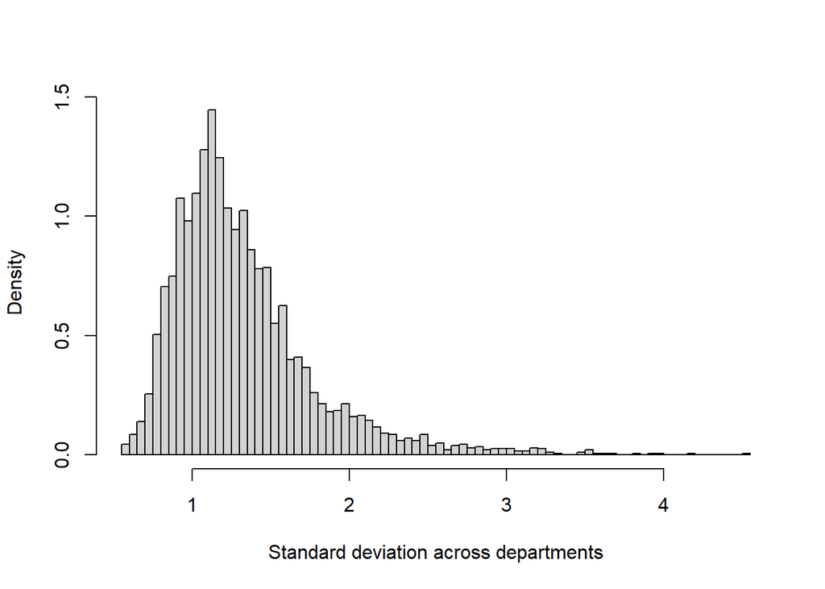

```r
hist(ps$sd_dept__Intercept, 100, freq = F,
     xlab = "Standard deviation across departments",
     main = "")
```

The parameters `r_dept[{A-F},Intercept]` are the deviations from the overall averages for each department. So department *A* and *B* have much greater than average admission rates, *C* and *D* are slightly below average, and *E* and *F* are well below average.

Finally, let’s compare the models with the computed PSIS-LOO estimate of ELPD:

```r
loo_compare(m11.7,m11.8,m12.1,m13.1, criterion = "loo")
```

```
##       elpd_diff se_diff
## m11.8    0.0       0.0
## m13.1   -8.2       7.0
## m12.1  -11.9       7.9
## m11.7 -423.5     157.0
```

Models m11.8 (*gender* and unique intercepts per *department*) and m13.1 (*gender* and partially pooled intercepts per *department*) rank highest according to PSIS-LOO. These are the two models that explicitly include *department* as a predictor. Model m12.1, however, is not discernibly worse; it doesn’t explicitly account for *department*, but it allows for high variation via the beta-binomial likelihood. Model m11.7, in contrast, has significantly less predictive power than the other models. It only considers *gender*.